# Reproducible Research 1

TZ

November, 2015

## Introduction

The dataset for this project is stored in a comma-separated-value (CSV) file and there are a total of 17,568 observations in this dataset.

The variables included in this dataset are:

-steps: Number of steps taking in a 5-minute interval (missing values are coded as NA) -date: The date on which the measurement was taken in YYYY-MM-DD format -interval: Identifier for the 5-minute interval in which measurement was taken

## Loading and preprocessing the data

The dataset is loaded to “amd”. It appears that there are some missing values. For this part of the assignment, the missing values in the dataset are ignored.

```r
amd<-read.csv("activity.csv")
```

## What is mean total number of steps taken per day?

The histgram (Fig. 1) of total number of steps per day is plotted. The mean steps per day is 10,766.2, and the median is 10,765.

```r
steps_per_day<-tapply(amd$steps,amd$date,sum)
mean_steps<-mean(steps_per_day,na.rm=T)
median_steps<-median(steps_per_day,na.rm=T)
mean_steps
```

```
## [1] 10766.19
```

```r
median_steps
```

```
## [1] 10765
```

## What is the average daily activity pattern?

A plot (Fig. 2) is made for daily activity pattern. The x-axis is the hour (0 is corresponding to 12 AM, and 1500 is corresponding to 3 PM). The y-axis is the average number of steps within the 5 minutes interval.From the plot, most steps (~206 steps) were walked during 8:35 AM and 8:40 AM.There appears to be 3 other peaks with ~100 average steps, at around 12 noon, 3:30 PM and 6:30 PM, respectively.

```r
steps_5min<-vector("numeric", length = 288)
hr24<-vector("numeric",length=288)
for (i in 1:288)
  {timehr<-floor((i*5-5)/60);
  timemi<-(i*5-5)%%60
  hr24[i]<-timehr*100+timemi
  amd_interval<-amd[amd$interval==hr24[i],]
  steps_5min[i]<-mean(amd_interval$steps,na.rm=T)}
which.max(steps_5min)
```

```
## [1] 104
```

```r
hr24[which.max(steps_5min)]
```

```
## [1] 835
```

```r
steps_5min[which.max(steps_5min)]
```

```
## [1] 206.1698
```

### Calculate and report the total number of missing values in the dataset (i.e. the total number of rows with NAs)

There are 2,304 days/intervals where there are missing values (coded as NA).

## Imputing missing values

In this study, it is assumed that the missing value equals to the mean steps at the same time interval of all other days with the step values. Once the missing values are replaced by the above strategy, it appears that the mean remains the same, and median of total daily steps only changes slightly.

```r
amd_complete<-amd[!is.na(amd$steps),]
nrow(amd)-nrow(amd_complete)
```

```
## [1] 2304
```

```r
amd_full<-amd;
for (i in 1:nrow(amd_full))
  {num5<- floor(amd_full[i,3]/100)*12+amd_full[i,3]%%100/5+1;
  if (is.na(amd_full[i,1])) {amd_full[i,1]<-steps_5min[num5]}
  }
nrow(amd_full[!is.na(amd_full$steps),])
```

```
## [1] 17568
```

```r
steps_per_day_full<-tapply(amd_full$steps,amd_full$date,sum)
mean(steps_per_day_full)
```

```
## [1] 10766.19
```

```r
median(steps_per_day_full)
```

```
## [1] 10766.19
```

## Are there differences in activity patterns between weekdays and weekends?

### Create a new factor variable in the dataset with two levels - “weekday” and “weekend” indicating whether a given date is a weekday or weekend day.

```r
dow<-weekdays(as.Date(amd$date))
amd_full[,"doweek"]<-dow
for (i in 1:nrow(amd_full))
  {
  if (amd_full[i,4]=="Saturday" || amd_full[i,4]=="Sunday") {amd_full[i,4]<-"weekend"}
  else (amd_full[i,4]<-"weekday")
  }
steps_5min_wday<-vector("numeric",length=288)
steps_5min_wend<-vector("numeric",length=288)
for (i in 1:288)
  {
  timehr<-floor((i*5-5)/60);
  timemi<-(i*5-5)%%60
  hr24[i]<-timehr*100+timemi
  amd_interval<-amd_full[amd_full$interval==hr24[i],]
  swday<-amd_interval[amd_interval$doweek=="weekday",]
  swend<-amd_interval[amd_interval$doweek=="weekend",]
  steps_5min_wday[i]<-mean(swday$steps,na.rm=T)
  steps_5min_wend[i]<-mean(swend$steps,na.rm=T)
  }
```

### Answer: There are differences in activity patterns

As shown in the panel plot, the weekday activity peaks at 8:35 AM, with more than 200 average steps, with 3 other smaller peaks ranging from 80 to 120 steps. Whereaz during weekends, there steps are more evenly distributed, with about 5 peaks each of which is about 80 - 160 steps.

[figure not shown]

[figure not shown]

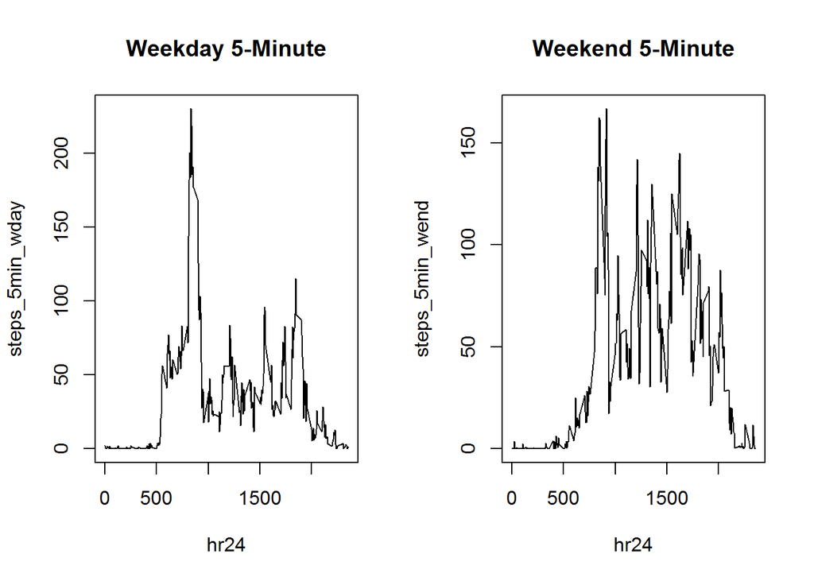